# Capstone Project for Data Science Specialization Coursera

Sabin Khadka

March 10, 2016

## Week 2 milestone report

### Executive summary

The report is a part of [Data Science Specialization](https://www.coursera.org/specializations/jhu-data-science) capstone project. The purpose of this report is to do the exploration of data set provided. The dataset provided for the current project was provided here in the [link](https://d396qusza40orc.cloudfront.net/dsscapstone/dataset/Coursera-SwiftKey.zip).

Downloading the dataset for the project.

```r
dirpath <- "/Users/sabinkhadka/Github/DataScience-Capstone/"
setwd(dirpath)
#download file from URL
fileurl <- "https://d396qusza40orc.cloudfront.net/dsscapstone/dataset/Coursera-SwiftKey.zip"
if (!file.exists(file.path(dirpath,"Data.zip"))) {
        download.file(fileurl, dest="Data.zip", method="curl",
                      quiet = FALSE, mode = "wb", cacheOK = TRUE)
}
if (!file.exists(file.path(dirpath,"final"))){
        unzip("Data.zip", files = NULL, list = FALSE, overwrite = TRUE,
              junkpaths = FALSE, exdir = ".", unzip = "internal")
}
```

In this project, we will only use the english language. The files we’d be using are:

1. en_US.blogs.txt : 200 MB
2. en_US.news.txt : 196 MB
3. en_US.twitter.txt : 159 MB

=============================================================================

```r
library("tm")
library("ggplot2")
library("xtable")
library("RWeka")
library("wordcloud")
blog <- paste0(dirpath, "final/en_US/",dir(paste0(dirpath,"/final/en_US"))[1])
blog_ <- readLines(blog)
len_blog <- length(blog_)
news <- paste0(dirpath, "final/en_US/",dir(paste0(dirpath,"/final/en_US"))[2])
news_ <- readLines(news)
len_news <- length(news_)
twit <- paste0(dirpath, "final/en_US/",dir(paste0(dirpath,"/final/en_US"))[3])
twit_ <- readLines(twit)
len_twit <- length(twit_)
info <- as.data.frame(matrix(data = NA, nrow=3, ncol=3))
colnames(info) <- c("file name", "size (MB)", "#lines")
info[1,1] <- dir(paste0(dirpath,"/final/en_US"))[1]
info[1,2] <- round(file.info(paste0(dirpath, "final/en_US/",dir(paste0(dirpath,"/final/en_US"))[1]))$size/1024^2)
info[2,1] <- dir(paste0(dirpath,"/final/en_US"))[2]
info[2,2] <- round(file.info(paste0(dirpath, "final/en_US/",dir(paste0(dirpath,"/final/en_US"))[2]))$size/1024^2)
info[3,1] <- dir(paste0(dirpath,"/final/en_US"))[3]
info[3,2] <- round(file.info(paste0(dirpath, "final/en_US/",dir(paste0(dirpath,"/final/en_US"))[3]))$size/1024^2)
info[1,3] <- len_blog
info[2,3] <- len_news
info[3,3] <- len_twit
```

```r
library(xtable)
tab <- xtable(info)
print(tab, type="html", align="c")
```

|  | file name | size (MB) | #lines |
| --- | --- | --- | --- |
| 1 | en_US.blogs.txt | 200.00 | 899288 |
| 2 | en_US.news.txt | 196.00 | 1010242 |
| 3 | en_US.twitter.txt | 159.00 | 2360148 |

```r
set.seed(0)
blog__ <- blog_[as.logical(rbinom(length(blog_), 1, prob=0.05))]
news__ <- news_[as.logical(rbinom(length(news_), 1, prob=0.05))]
twit__ <- twit_[as.logical(rbinom(length(twit_), 1, prob=0.05))]
merge_all <- c(blog__, news__, twit__, recursive=TRUE)
dir.create(paste0(dirpath,"temp"))
```

```r
if (!file.exists(file.path(paste0(dirpath,"temp/temp_merge.txt")))) {
        writeLines(merge_all, paste0(dirpath,"temp/temp_merge.txt"))
        } else {
                file.remove(file.path(paste0(dirpath,"temp/temp_merge.txt")))
                writeLines(merge_all, paste0(dirpath,"temp/temp_merge.txt"))
        }
Sample_docs <- Corpus(DirSource(paste0(dirpath, "temp")))
```

For preprocessing of the subset of corpora we’ll do the following:

```r
Corp_sample <- Sample_docs
Corp_sample <- tm_map(Corp_sample, stripWhitespace)
Corp_sample <- tm_map(Corp_sample, removePunctuation)
Corp_sample <- tm_map(Corp_sample, removeNumbers)
Corp_sample <- tm_map(Corp_sample, removeWords, stopwords("english"))
Corp_sample <- tm_map(Corp_sample, content_transformer(tolower))
#subCorpus <- tm_map(subCorpus, PlainTextDocument)
#dtf <- DocumentTermMatrix(subCorpus)
Token_1 <- function(x) {
        NGramTokenizer(x, Weka_control(min = 1, max = 1))
        }
Token_2 <- function(x) {
        NGramTokenizer(x, Weka_control(min = 2, max = 2))
        }
Token_3 <- function(x) {
        NGramTokenizer(x, Weka_control(min = 3, max = 3))
        }
SampleDoc_unigram <- DocumentTermMatrix(Corp_sample, control = list(tokenize = Token_1))
SampleDoc_bigram  <- DocumentTermMatrix(Corp_sample, control = list(tokenize = Token_2))
SampleDoc_trigram <- DocumentTermMatrix(Corp_sample, control = list(tokenize = Token_3))
Sample_unigram_freq <- sort(colSums(as.matrix(SampleDoc_unigram)), decreasing=TRUE)
Sample_bigram_freq  <- sort(colSums(as.matrix(SampleDoc_bigram)), decreasing=TRUE)
Sample_trigram_freq <- sort(colSums(as.matrix(SampleDoc_trigram)), decreasing=TRUE)
Sample_unigramFreq <- data.frame(word=names(Sample_unigram_freq), freq=Sample_unigram_freq)
Sample_bigramFreq <- data.frame(word=names(Sample_bigram_freq), freq=Sample_bigram_freq)
Sample_trigramFreq <- data.frame(word=names(Sample_trigram_freq), freq=Sample_trigram_freq)
```

Figure below shows the top 25th frequent unigram words.

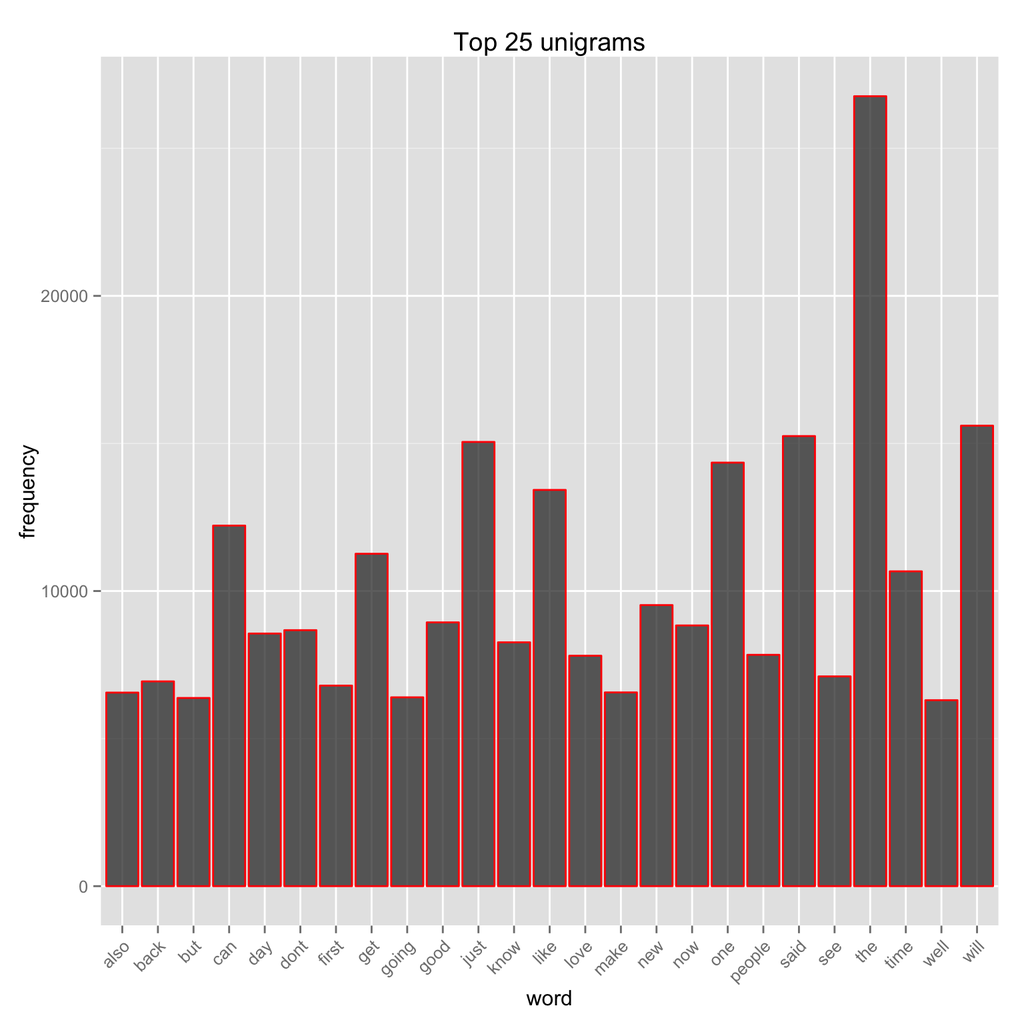

Word cloud of the top 100 unigram words

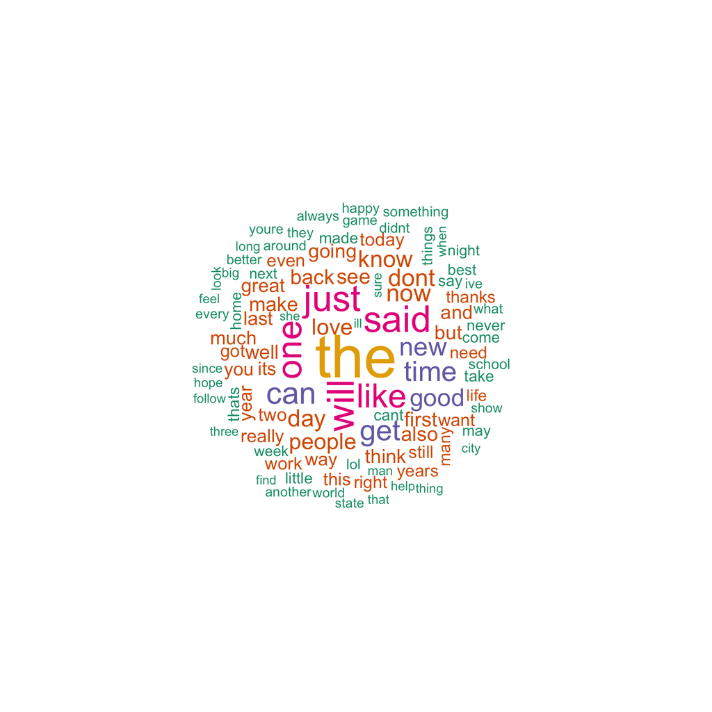

Figure below shows the top 25th frequent bigram words.

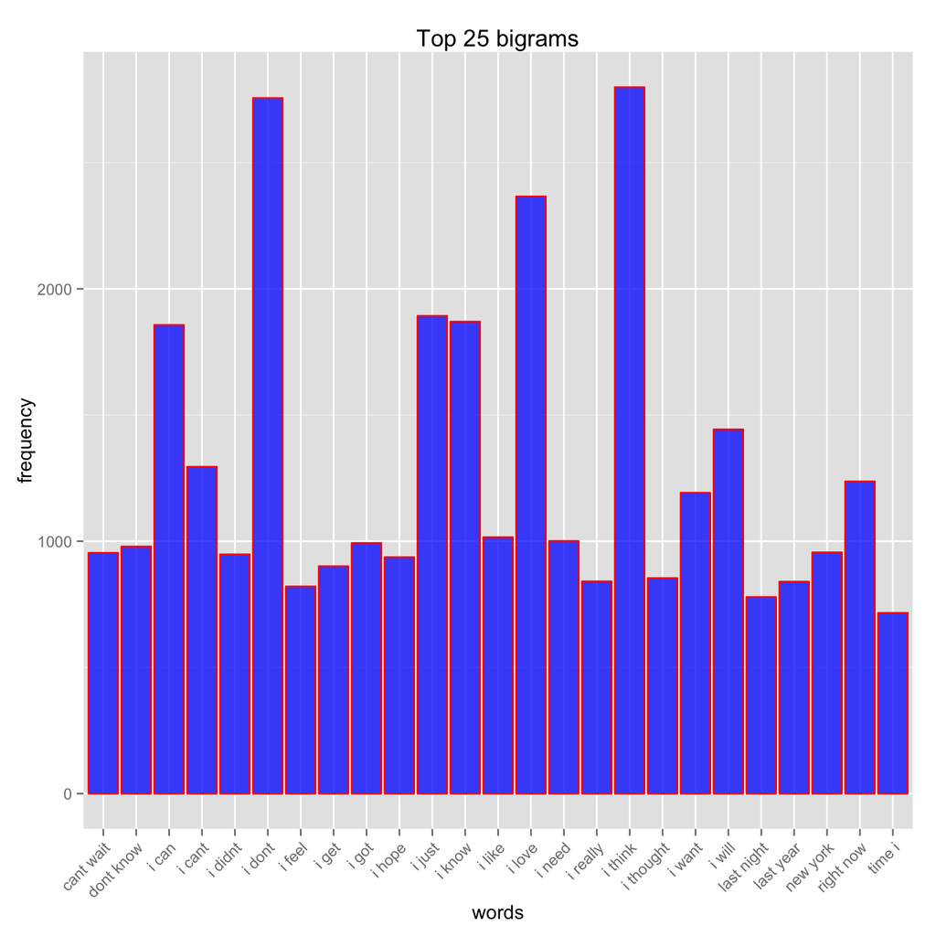

Word cloud of the top 100 bigram words

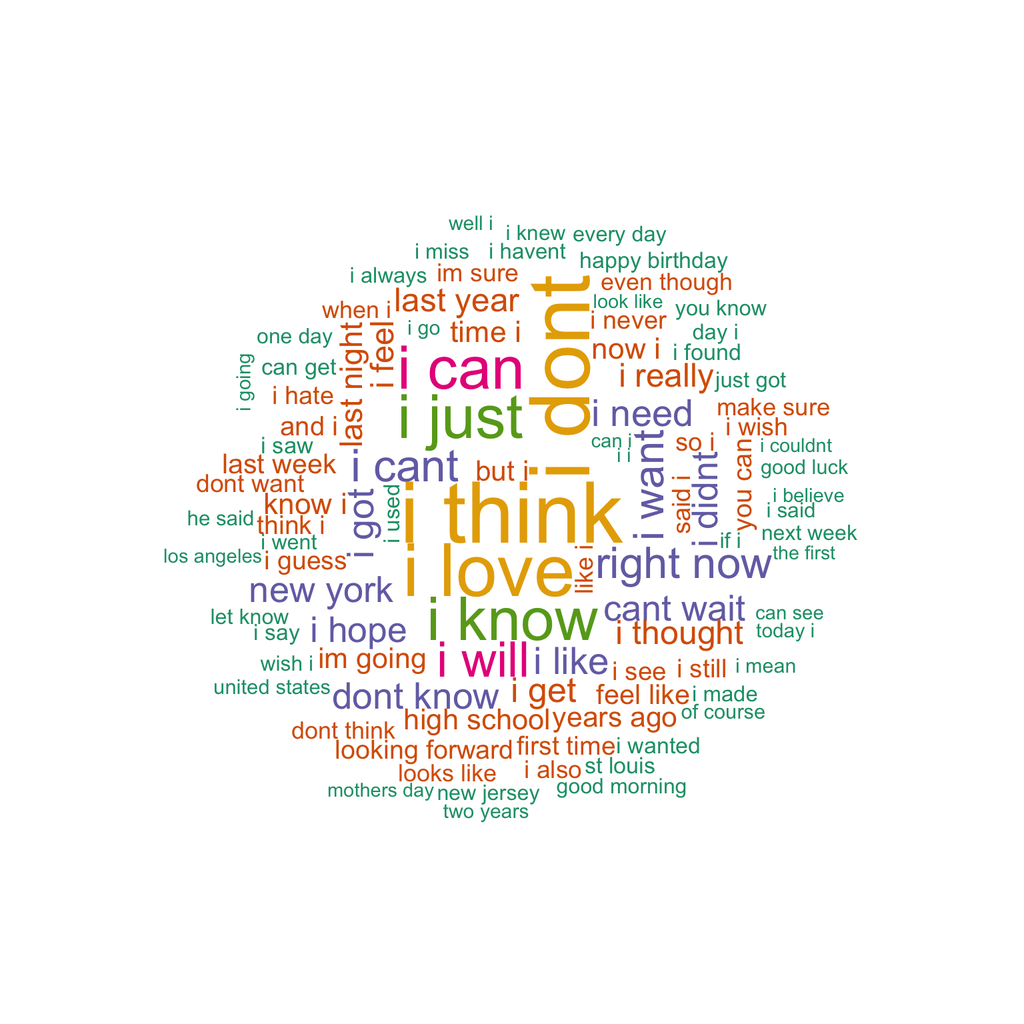

Figure below shows the top 25th frequent trigram words.

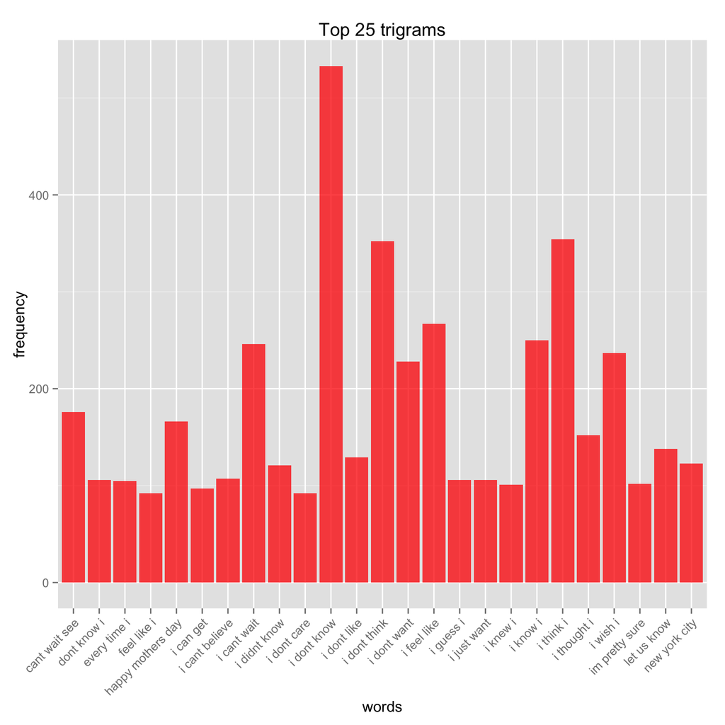

Word cloud of the top 100 trigram words

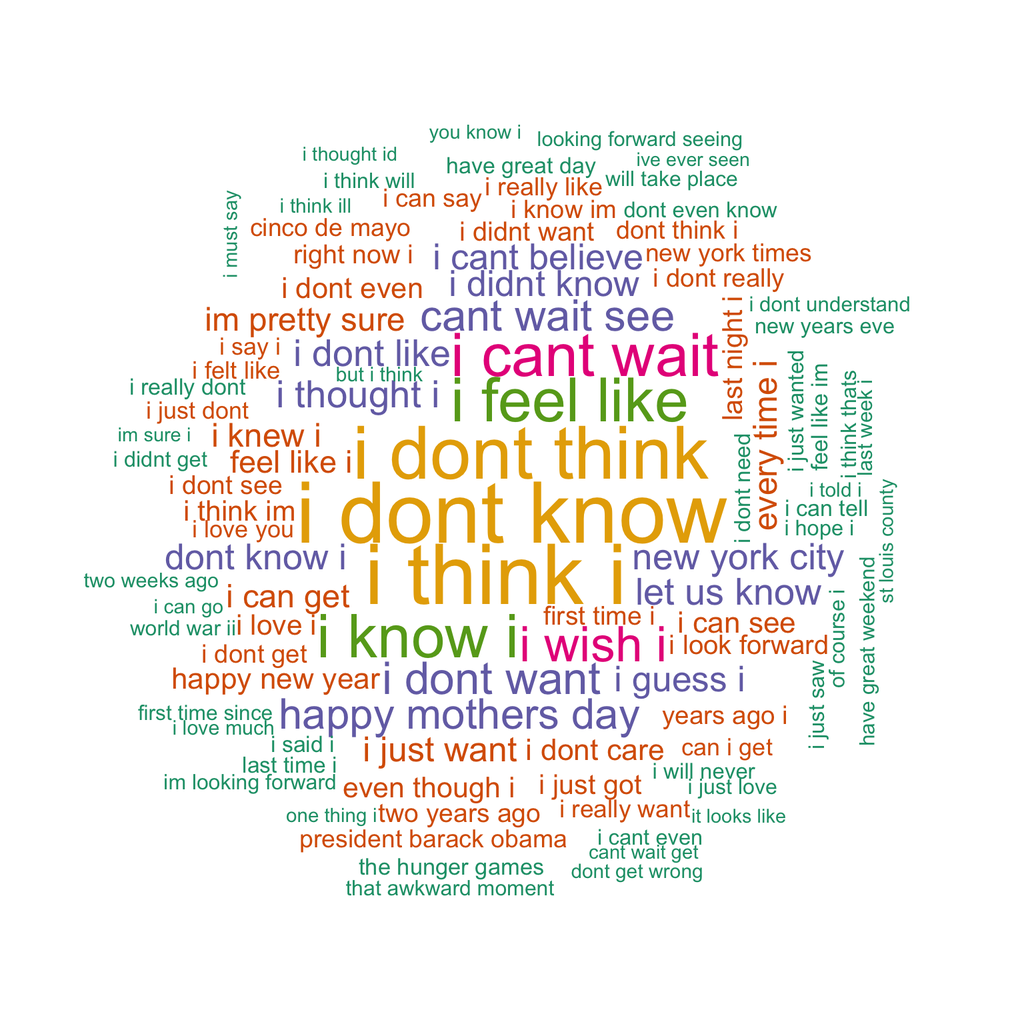

### Summary

Here we explore few techniques to clean the data. Also, tokenized the data in order to see the frequently used words and word combinations from en_US.news.txt, en_US.blogs.txt and en_US.twitter.txt files using n-gram tokenizer function as employed in [tm](https://cran.r-project.org/web/packages/tm/index.html) package. The final goal of the project is to build the prediction model, that predicts the next word based on the already typed words and optimize the model in terms of efficiency and accuracy.

This is work in progress report. Any feedback/constructive criticisms from the peers would be highly appreciated.

#### Sources

1. https://cran.r-project.org/web/packages/tm/tm.pdf
2. http://www.rdatamining.com/examples/text-mining
3. http://www.sthda.com/english/wiki/text-mining
4. Also RWeka, wordcloud